# Data_project_visualization

## Dataset

We get data from url: https://www.kaggle.com/aaron7sun/stocknews

This dataset consists with 3 csv files. Combined_News_DJIA.csv and RedditNews.csv contains the top headline news categorized by date DJIA_table.csv contains the Dow Jones Industrial Average Index containing Opening price, High price, Low price, Closing price, Volume etc.

## Preparations

### Software Installation

```python
import nltk
nltk.download()
```

```
NLTK Downloader
---------------------------------------------------------------------------
    d) Download   l) List    u) Update   c) Config   h) Help   q) Quit
---------------------------------------------------------------------------
Downloader> q
```

```
True
```

```python
!pip install wordcloud
from nltk import *
from wordcloud import WordCloud, STOPWORDS
import matplotlib.pyplot as plt
%matplotlib inline
```

### Open File and Data Preprocessing

'data' is a DataFrame.

```python
import pandas as pd
import numpy as np
data_ = pd.read_csv('Combined_News_DJIA.csv')
data = data_.dropna()
date = data.iloc[:,0]
actual_label = data.iloc[:,1]
```

And 'pure_text_string' is a string.

```python
import csv
import collections
with open('Combined_News_DJIA.csv') as file:
    reader = csv.reader(file)
    text = list(reader)

l = len(text)
pure_text = []
for i in range(l-1):
    row_text = list(text[i+1][2:])
    pure_text.append(row_text)

pure_text_string = ''
for row in pure_text:
    for line in row:
        pure_text_string += line
```

## Intuitions from our data

### Word Cloud

All the headlines

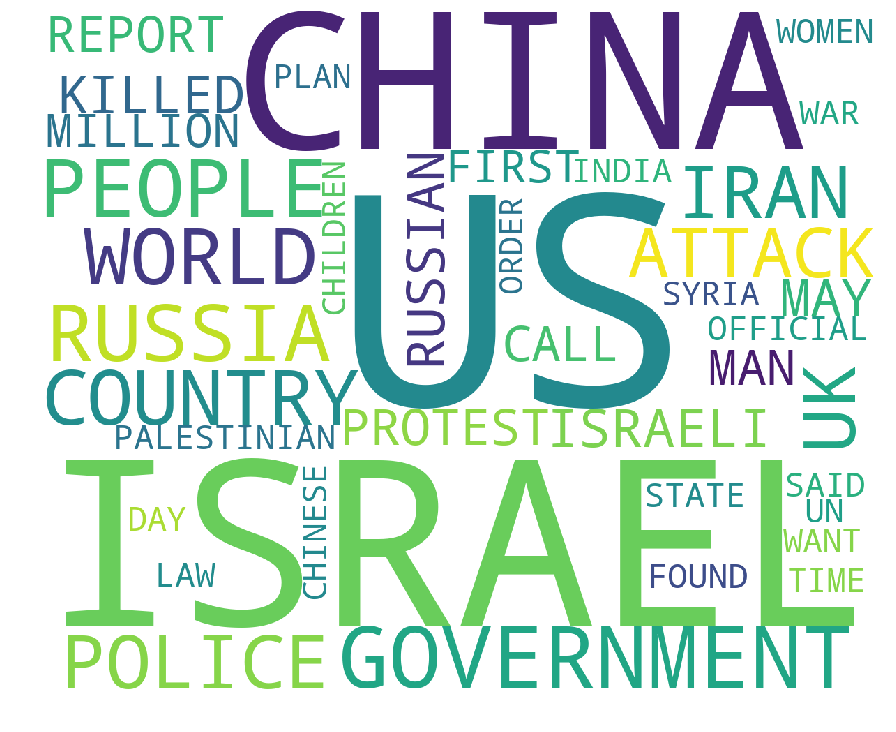

```python
DELETE_WORDS = ['AMP','EEN','UT','EING','ONE','TWO','YEAR','OLD','USE']
def remove_words(text_string,DELETE_WORDS=DELETE_WORDS):
    for word in DELETE_WORDS:
        text_string = text_string.replace(word,' ')
    return text_string

MIN_LENGTH = 3
def remove_short_words(text_string,min_length = MIN_LENGTH):
    for word in line:
        if len(word) < min_length:
            text_string = text_string.replace(word,' ',1)
    return text_string

pure_text_string = pure_text_string.upper()
pure_text_string = remove_words(pure_text_string)
pure_text_string = remove_short_words(pure_text_string,3)
from wordcloud import WordCloud, STOPWORDS
wordcloud = WordCloud(stopwords=STOPWORDS,background_color='white',width=1200,height=1000,max_words=40).generate(pure_text_string)
plt.figure(figsize=(15,15))
plt.imshow(wordcloud)
plt.axis('off')
plt.show()
```

### Entity Dispersion Plot

Get frequent mentioned countries during different period from text.

Get frequent mentioned entity during different period from text.

Get relationship between behaviors.

1. 'BUY' is far more less than 'SELL' --> Negative news have bigger effects on market behavior.
2. Market behavior is a little lagged behind the negative news.

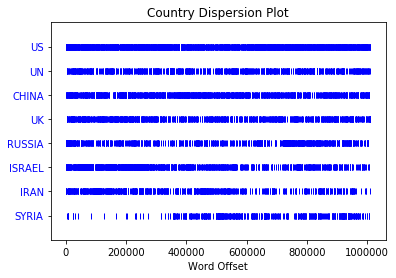

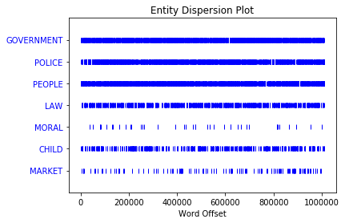

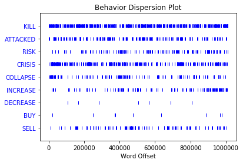

```python
import nltk
frequent_country = ['US','UN','CHINA','UK','RUSSIA','ISRAEL','IRAN','SYRIA']
pure_text = pure_text_string.split(' ')
country_dispersion = nltk.draw.dispersion.dispersion_plot(pure_text,frequent_country,title="Country Dispersion Plot")
frequent_entity = ['GOVERNMENT','POLICE','PEOPLE','LAW','MORAL','CHILD','MARKET']
entity_dispersion = nltk.draw.dispersion.dispersion_plot(pure_text,frequent_entity,title="Entity Dispersion Plot")
frequent_verb = ['KILL','ATTACKED','RISK','CRISIS','COLLAPSE','INCREASE','DECREASE','BUY','SELL']
behavior_dispersion = nltk.draw.dispersion.dispersion_plot(pure_text,frequent_verb,title="Behavior Dispersion Plot")
```

## Sentiment Analysis

Use nltk package SIA to do sentiment analysis.

Results are visualized by graphs.

### Get sentiment compounds

```python
def SentiAna1(results):
    sum_ = 0
    for item in results:
        sum_ += item['compound']
    average_ = sum_/(len(results))
    return average_
```

```python
def SentiAna2(results):
    sum_ = 0
    for item in results:
        sum_ += item['compound']
    average_ = sum_/(len(results))
    if average_ > -0.2:
        a = 1
    else:
        a = 0
    return a
```

```python
from nltk.sentiment.vader import SentimentIntensityAnalyzer as SIA
sia = SIA()
result_label = []
results_compound = []
for i in range(1986):
    headlines = data.iloc[i,2:]
    results = []
    for line in headlines:
        pol_score = sia.polarity_scores(str(line))
        pol_score['headline'] = line
        results.append(pol_score)
    results_compound.append(SentiAna1(results))
    result_label.append(SentiAna2(results))
```

### Plot the news sentiment compounds to see how it vary in a year.

```python
import datetime
date.apply(lambda x:datetime.datetime.strptime(x,'%Y-%m-%d'))
title = ['2008-2009',
         '2009-2010',
         '2010-2011',
         '2011-2012',
         '2012-2013',
         '2013-2014',
         '2014-2015',
         '2015-2016']
year = pd.Series(['2008-08-07',
                  '2009-08-07',
                  '2010-08-07',
                  '2011-08-07',
                  '2012-08-07',
                  '2013-08-07',
                  '2014-08-07',
                  '2015-08-07',
                  '2016-07-02'])
year.apply(lambda x:datetime.datetime.strptime(x,'%Y-%m-%d'))
date_ = [[],[],[],[],[],[],[],[]]
for day in date:
    for i in range(8):
        if day > year[i] and day < year[i+1]:
            date_[i].append(day)
date_
length = []
for i in range(8):
    length.append(len(date_[i]))
```

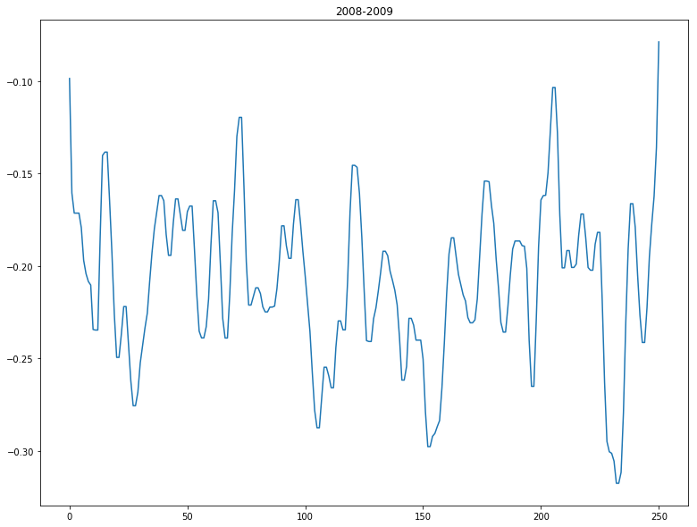

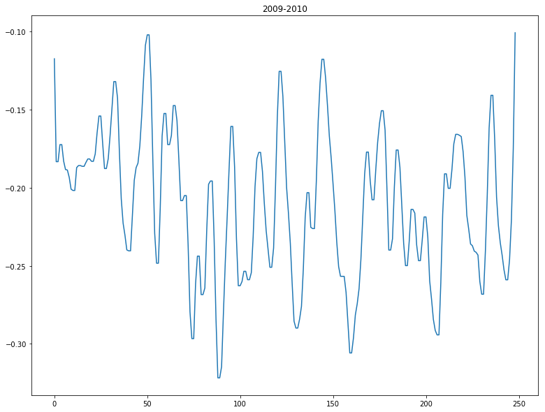

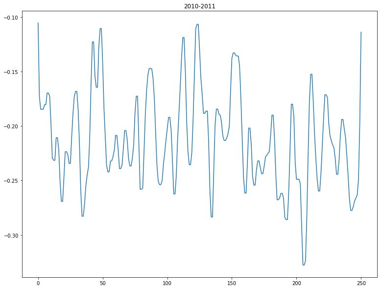

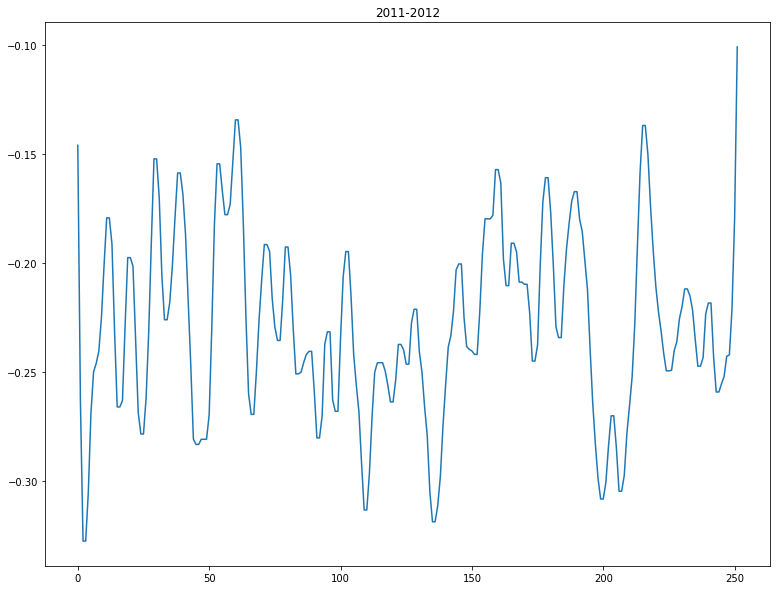

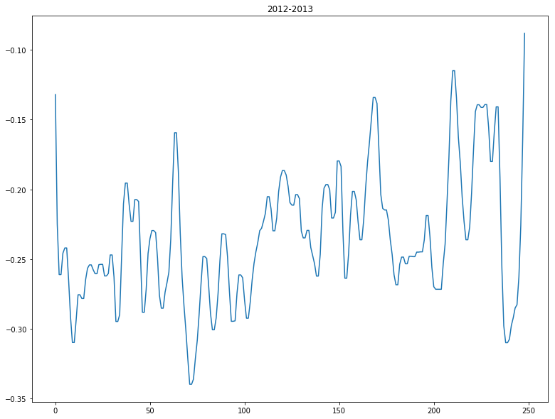

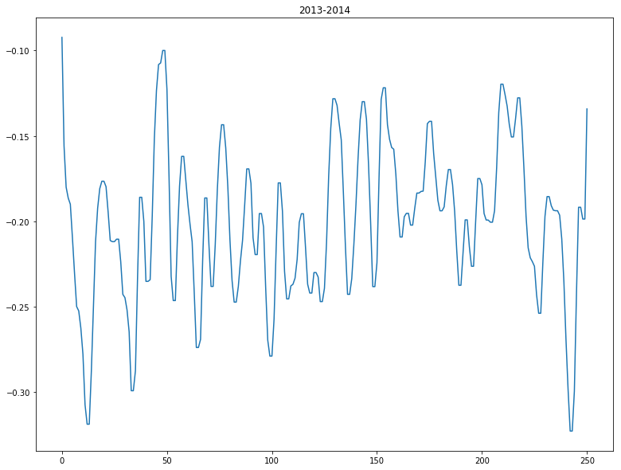

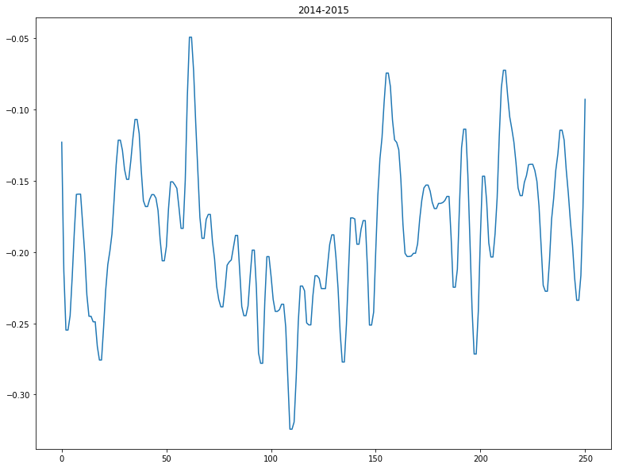

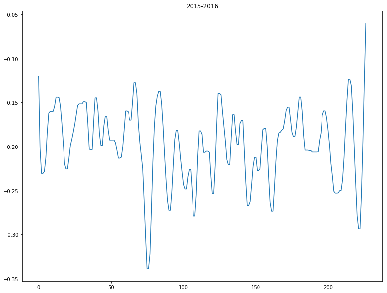

```python
mark = 0
import matplotlib.pyplot as plt
%matplotlib inline
import scipy
from scipy import signal
for i in range(8):
    x_axis = list(date_[i])
    y_axis = results_compound[mark:mark+len(x_axis)]
    mark = mark+len(x_axis)
    fig = plt.figure(figsize=(13, 10))
    plt.plot(scipy.signal.medfilt(scipy.signal.medfilt(scipy.signal.medfilt(scipy.signal.medfilt(scipy.signal.medfilt(scipy.signal.medfilt(scipy.signal.medfilt(scipy.signal.wiener(scipy.signal.wiener(scipy.signal.wiener(y_axis,noise=20),noise=20),noise=20)))))))))
    plt.title(title[i])
    plt.show()
```

### Pie Chart of comparison:

Headline labels get from Sentiment Analysis VS Actual stock market labels.

```python
def labeling(list_):
    label_0 = 0
    label_1 = 0
    for i in list_:
        if i == 0:
            label_0 +=1
        else:
            label_1 += 1
    return [label_0,label_1]
```

```python
actual = labeling(actual_label)
predicted = labeling(result_label)
```

```python
import random
from pyecharts import Pie

comparison = Pie("Actual_Stock_Label VS Sentiment_Label", width=1000, height=600)
comparison.add(
    "Actual Label",
    ['label_0','label_1'],
    actual,
    radius=[0, 45],
    )
comparison.add(
    "Sentiment Label",
    ['label_0','label_1'],
    predicted,
    radius=[50, 65],
    )
comparison
```

[output not shown]

### Words contribute most to negative news.

Results are get from CountVectorizer + Logistic Regression model.

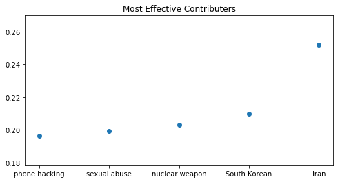

```python
import matplotlib.pyplot as plt
%matplotlib inline

plt.figure(1, figsize=(8, 4))
y = [0.196295, 0.199183, 0.203194, 0.209913, 0.251981]
x= ['phone hacking', 'sexual abuse', 'nuclear weapon', 'South Korean', 'Iran']
plt.scatter(x, y)
plt.title("Most Effective Contributers")
plt.show()
```